# Regression Analysis of Mortality Rates across U.S. Cities: Final Report

Stefano Nogueira

## Introduction

In their 1973 study, McDonald and Schwing introduced a dataset to examine the correlation between total mortality and various influencing factors, such as climate, socioeconomic conditions, and pollution, across 60 U.S. cities in 1960. This project performs regression analysis with total age-adjusted mortality from all causes as the response variable. The analysis identifies key predictors of mortality rates and explores how these factors vary across different cities.

Below are the fifteen predictor variables selected for the study:

**Variable – Description**

X1 – Mean annual precipitation (inches)  
X2 – Mean January temperature (degrees Fahrenheit)  
X3 – Mean July temperature (degrees Fahrenheit)  
X4 – Percent of population over 65 years of age  
X5 – Population per household  
X6 – Median school years completed  
X7 – Percent of housing units that are sound  
X8 – Population per square mile  
X9 – Percent of nonwhite population  
X10 – Percent employment in white-collar jobs  
X11 – Percent of families with income under $3000  
X12 – Relative pollution potential of hydrocarbons  
X13 – Relative pollution potential of oxide of nitrogen  
X14 – Relative pollution potential of sulfur dioxide  
X15 – Percent relative humidity  
Y – Total age-adjusted mortality from all causes

## Exploratory Data Analysis

First, let’s assess the data types in our dataframe

```r
str(data)
```

```
## 'data.frame':    60 obs. of  16 variables:
##  $ X1 : int  36 35 44 47 43 53 43 45 36 36 ...
##  $ X2 : int  27 23 29 45 35 45 30 30 24 27 ...
##  $ X3 : int  71 72 74 79 77 80 74 73 70 72 ...
##  $ X4 : num  8.1 11.1 10.4 6.5 7.6 7.7 10.9 9.3 9 9.5 ...
##  $ X5 : num  3.34 3.14 3.21 3.41 3.44 3.45 3.23 3.29 3.31 3.36 ...
##  $ X6 : num  11.4 11 9.8 11.1 9.6 10.2 12.1 10.6 10.5 10.7 ...
##  $ X7 : num  81.5 78.8 81.6 77.5 84.6 66.8 83.9 86 83.2 79.3 ...
##  $ X8 : int  3243 4281 4260 3125 6441 3325 4679 2140 6582 4213 ...
##  $ X9 : num  8.8 3.5 0.8 27.1 24.4 38.5 3.5 5.3 8.1 6.7 ...
##  $ X10: num  42.6 50.7 39.4 50.2 43.7 43.1 49.2 40.4 42.5 41 ...
##  $ X11: num  11.7 14.4 12.4 20.6 14.3 25.5 11.3 10.5 12.6 13.2 ...
##  $ X12: int  21 8 6 18 43 30 21 6 18 12 ...
##  $ X13: int  15 10 6 8 38 32 32 4 12 7 ...
##  $ X14: int  59 39 33 24 206 72 62 4 37 20 ...
##  $ X15: int  59 57 54 56 55 54 56 56 61 59 ...
##  $ Y  : num  922 998 962 982 1071 ...
```

As well as obtaining some descriptive statistics for each of the variables

```r
summary(data)
```

```
##        X1              X2              X3              X4
##  Min.   :10.00   Min.   :12.00   Min.   :63.00   Min.   : 5.600
##  1st Qu.:32.75   1st Qu.:27.00   1st Qu.:72.00   1st Qu.: 7.675
##  Median :38.00   Median :31.50   Median :74.00   Median : 9.000
##  Mean   :37.37   Mean   :33.98   Mean   :74.58   Mean   : 8.798
##  3rd Qu.:43.25   3rd Qu.:40.00   3rd Qu.:77.25   3rd Qu.: 9.700
##  Max.   :60.00   Max.   :67.00   Max.   :85.00   Max.   :11.800
##        X5              X6              X7              X8             X9
##  Min.   :2.920   Min.   : 9.00   Min.   :66.80   Min.   :1441   Min.   : 0.80
##  1st Qu.:3.210   1st Qu.:10.40   1st Qu.:78.38   1st Qu.:3104   1st Qu.: 4.95
##  Median :3.265   Median :11.05   Median :81.15   Median :3567   Median :10.40
##  Mean   :3.263   Mean   :10.97   Mean   :80.91   Mean   :3876   Mean   :11.87
##  3rd Qu.:3.360   3rd Qu.:11.50   3rd Qu.:83.60   3rd Qu.:4520   3rd Qu.:15.65
##  Max.   :3.530   Max.   :12.30   Max.   :90.70   Max.   :9699   Max.   :38.50
##       X10             X11             X12              X13
##  Min.   :33.80   Min.   : 9.40   Min.   :  1.00   Min.   :  1.00
##  1st Qu.:43.25   1st Qu.:12.00   1st Qu.:  7.00   1st Qu.:  4.00
##  Median :45.50   Median :13.20   Median : 14.50   Median :  9.00
##  Mean   :46.08   Mean   :14.37   Mean   : 37.85   Mean   : 22.65
##  3rd Qu.:49.52   3rd Qu.:15.15   3rd Qu.: 30.25   3rd Qu.: 23.75
##  Max.   :59.70   Max.   :26.40   Max.   :648.00   Max.   :319.00
##       X14              X15              Y
##  Min.   :  1.00   Min.   :38.00   Min.   : 790.7
##  1st Qu.: 11.00   1st Qu.:55.00   1st Qu.: 898.4
##  Median : 30.00   Median :57.00   Median : 943.7
##  Mean   : 53.77   Mean   :57.67   Mean   : 940.4
##  3rd Qu.: 69.00   3rd Qu.:60.00   3rd Qu.: 983.2
##  Max.   :278.00   Max.   :73.00   Max.   :1113.2
```

**Exploring Quantitative Variables**

Exploring the distributions of some interesting variables in our data, we find the following graphs:

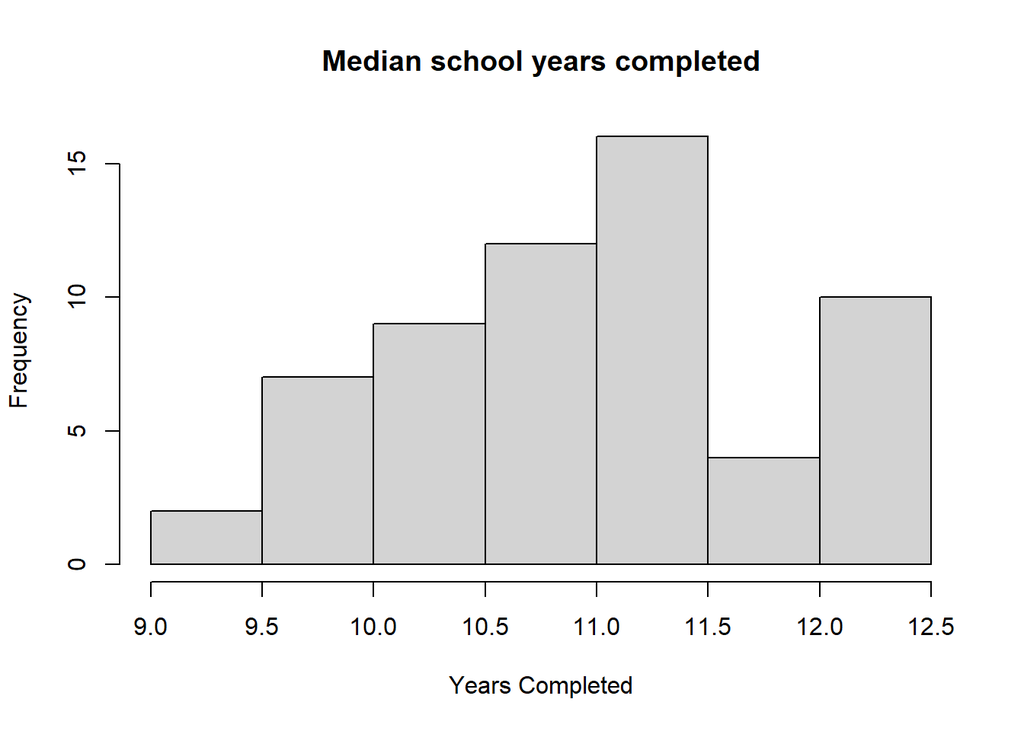

```r
hist(data$X6, main = "Median school years completed", xlab = "Years Completed", ylab = "Frequency")
```

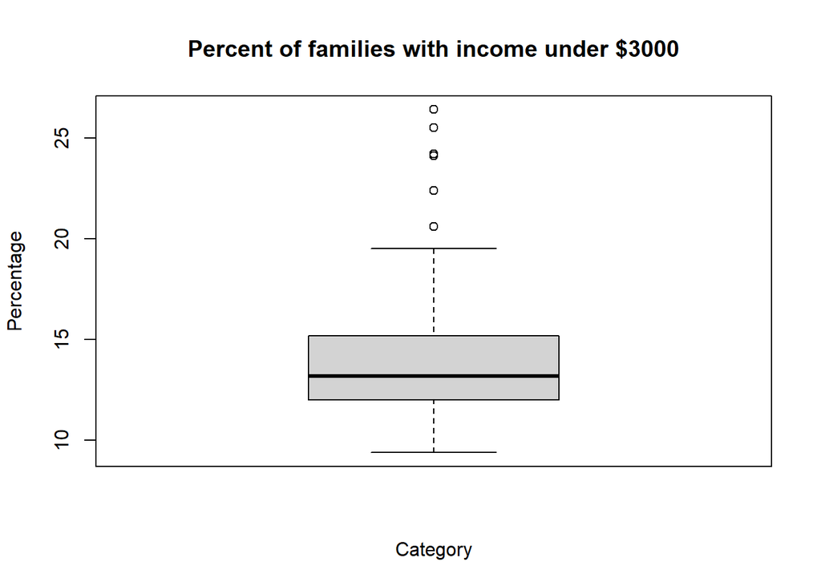

```r
boxplot(data[,c("X11")], main = "Percent of families with income under $3000", xlab = "Category", ylab = "Percentage")
```

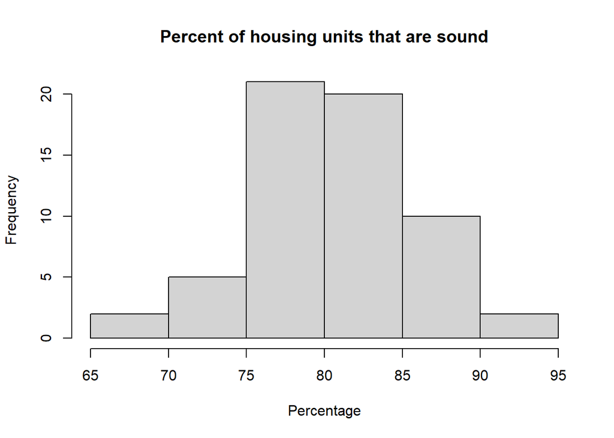

```r
hist(data$X7, main = "Percent of housing units that are sound", xlab = "Percentage", ylab = "Frequency")
```

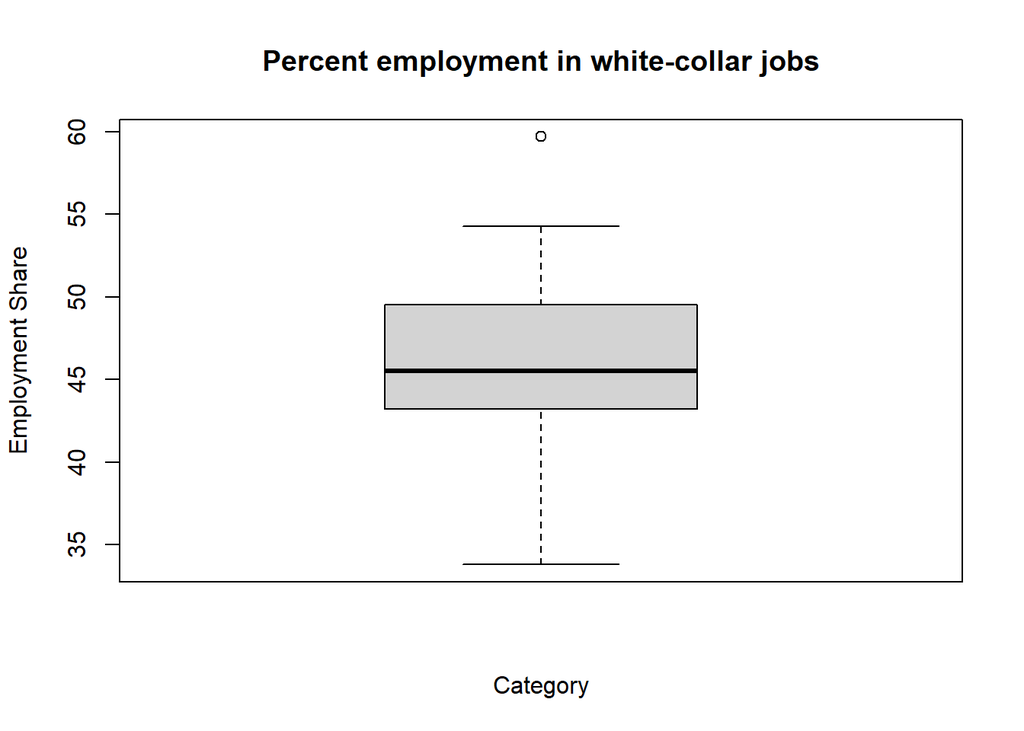

```r
boxplot(data[,c("X10")], main = "Percent employment in white-collar jobs", xlab = "Category", ylab = "Employment Share")
```

Finally, let’s explore the relationships between variables using a scatter plot matrix.

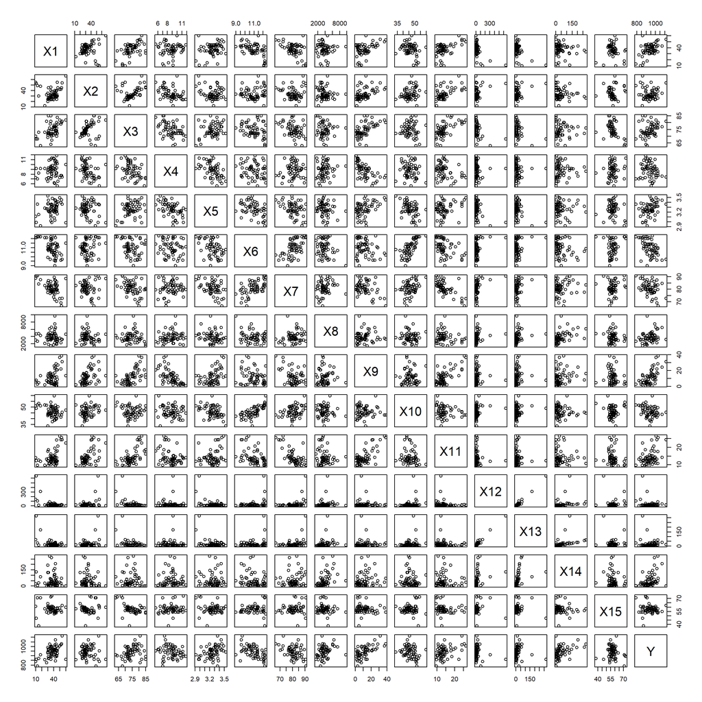

```r
pairs(data)
```

## Building a Regression Model

To select the best model, we’ll employ stepwise selection methods. With this technique we are able to identify the most relevant independent variables for our regression model as it iteratively adds or removes predictors based on their statistical significance.

Evaluating the following metrics we obtain:

```r
raw_fit <- lm(Y ~ ., data = data)
```

```r
summary(raw_fit)$r.squared # R^2
```

```
## [1] 0.7648778
```

```r
summary(raw_fit)$adj.r.squared # Adjusted R^2
```

```
## [1] 0.6847225
```

```r
summary(raw_fit)$sigma^2 # MSE
```

```
## [1] 1220.02
```

```r
AIC(raw_fit) # AIC
```

```
## [1] 612.0607
```

```r
BIC(raw_fit) # BIC
```

```
## [1] 647.6646
```

We’ll utilize the AIC model criterion.

```r
base_fit <- lm(Y ~ 1, data = data)
library(MASS)
fit <- stepAIC(base_fit, scope=list(upper=raw_fit), direction="forward", k=2)
```

```
## Start:  AIC=496.65
## Y ~ 1
##
##        Df Sum of Sq    RSS    AIC
## + X9    1     94613 133698 466.54
## + X6    1     59614 168697 480.49
## + X1    1     59267 169043 480.61
## + X7    1     41593 186718 486.58
## + X14   1     41413 186898 486.64
## + X11   1     38471 189840 487.58
## + X5    1     29148 199163 490.45
## + X10   1     18519 209792 493.57
## + X3    1     17520 210790 493.86
## + X8    1     16094 212217 494.26
## <none>              228311 496.65
## + X12   1      7172 221138 496.73
## + X4    1      6960 221351 496.79
## + X15   1      1788 226522 498.18
## + X13   1      1367 226943 498.29
## + X2    1       206 228105 498.59
##
## Step:  AIC=466.54
## Y ~ X9
##
##        Df Sum of Sq    RSS    AIC
## + X6    1     33855  99843 451.02
## + X2    1     29836 103862 453.39
## + X14   1     24493 109205 456.40
## + X4    1     21437 112261 458.05
## + X10   1     18154 115544 459.78
## + X8    1     16541 117157 460.62
## + X1    1     16325 117373 460.73
## + X7    1      7265 126433 465.19
## + X12   1      5892 127806 465.84
## <none>              133698 466.54
## + X3    1      2973 130725 467.19
## + X5    1      2112 131586 467.58
## + X13   1      1818 131880 467.72
## + X11   1       851 132847 468.16
## + X15   1        37 133661 468.52
```

[output cut: 84 more lines]

```
## + X11   1      0.23 60540 431.00
##
## Step:  AIC=428.83
## Y ~ X9 + X6 + X2 + X14 + X1 + X3 + X5
##
##        Df Sum of Sq   RSS    AIC
## <none>              58387 428.83
## + X4    1   1006.41 57380 429.79
## + X8    1    768.29 57619 430.04
## + X12   1    291.99 58095 430.53
## + X13   1     98.64 58288 430.73
## + X7    1     88.15 58299 430.74
## + X10   1     85.71 58301 430.74
## + X15   1     18.64 58368 430.81
## + X11   1      6.16 58381 430.82
```

```r
summary(fit)
```

```
##
## Call:
## lm(formula = Y ~ X9 + X6 + X2 + X14 + X1 + X3 + X5, data = data)
##
## Residuals:
##     Min      1Q  Median      3Q     Max
## -76.751 -21.037  -3.989  15.553  92.462
##
## Coefficients:
##               Estimate Std. Error t value Pr(>|t|)
## (Intercept) 1429.20063  215.75877   6.624 1.97e-08 ***
## X9             5.21611    0.82709   6.307 6.30e-08 ***
## X6           -16.96625    6.81964  -2.488  0.01609 *
## X2            -1.89343    0.58900  -3.215  0.00225 **
## X14            0.22530    0.08156   2.762  0.00792 **
## X1             1.64850    0.60345   2.732  0.00858 **
## X3            -2.30046    1.23396  -1.864  0.06793 .
## X5           -62.01704   44.78202  -1.385  0.17201
## ---
## Signif. codes:  0 '***' 0.001 '**' 0.01 '*' 0.05 '.' 0.1 ' ' 1
##
## Residual standard error: 33.51 on 52 degrees of freedom
## Multiple R-squared:  0.7443, Adjusted R-squared:  0.7098
## F-statistic: 21.62 on 7 and 52 DF,  p-value: 2.41e-13
```

Now let’s check for the presence of outliers. We can visualize them by examining the residuals.

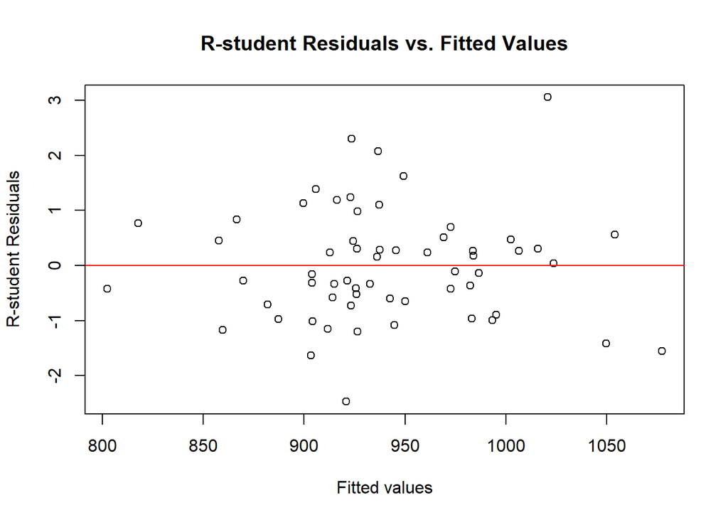

```r
plot(fit$fitted.values, rstandard(fit), xlab = "Fitted values", ylab = "R-student Residuals", main = "R-student Residuals vs. Fitted Values")
abline(h = 0, col = "red")
```

And check for any of them using a Bonferroni Test.

```r
outlierTest(fit)
```

```
## No Studentized residuals with Bonferroni p < 0.05
## Largest |rstudent|:
##    rstudent unadjusted p-value Bonferroni p
## 37 3.343158          0.0015578     0.093469
```

Therefore, by utilizing Bonferroni’s corrected p-value of 0.093469, we do not reject the null hypothesis. The point is not an outlier.

## Model Adequacy Checking

In order to ensure reliability in our analysis it’s imperative that our regression model adheres to the following assumptions:

1. The relationship between the response and the regressors is linear, at least approximately.
2. The error term (ε) has mean zero and constant variance (σ^2).
3. The errors are uncorrelated.
4. The errors are normally distributed.
5. The regressors are linearly independent.

In order to check for (a.) we examine our previous graph of residuals.

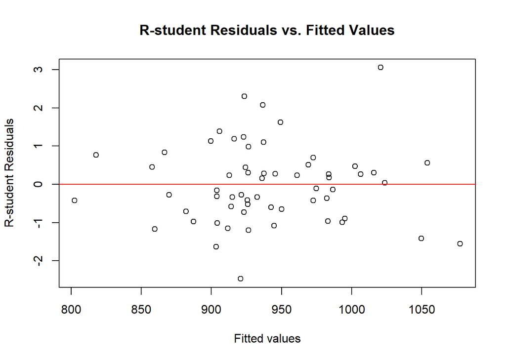

```r
plot(fit$fitted.values, rstandard(fit), xlab = "Fitted values", ylab = "R-student Residuals", main = "R-student Residuals vs. Fitted Values")
abline(h = 0, col = "red")
```

As the plot shows randomly scattered residuals around zero, it follows that the relationship between the response variable and the regressors is linear, at least approximately.

For part (b.) we first calculate the mean of the error term.

```r
mean_residuals <- mean(fit$residuals)
mean_residuals
```

```
## [1] -8.727249e-16
```

Which, indeed, is very close to zero.

And checking for non-constant variance we compute a Breusch-Pagan test.

```r
ncvTest(fit)
```

```
## Non-constant Variance Score Test
## Variance formula: ~ fitted.values
## Chisquare = 0.808405, Df = 1, p = 0.36859
```

With a p-value of 0.36859, there is insufficient evidence to reject the null hypothesis, suggesting that the assumption of constant variance is not violated.

Now we check for (c.) regarding uncorrelation by preforming a Durbin-Watson test.

```r
dw_test <- dwtest(fit)
print(dw_test)
```

```
##
##  Durbin-Watson test
##
## data:  fit
## DW = 2.0509, p-value = 0.5479
## alternative hypothesis: true autocorrelation is greater than 0
```

In this case, the test does not provide sufficient evidence to reject the null hypothesis of no autocorrelation, indicating that the assumption of uncorrelated errors holds.

In order to check for (d.) to assess whether the residuals of the regression model follow a normal distribution. We compute a Shapiro-Wilk test.

```r
residuals <- residuals(fit)
shapiro.test(residuals)
```

```
##
##  Shapiro-Wilk normality test
##
## data:  residuals
## W = 0.9767, p-value = 0.3051
```

Additionally, we can visualize this by using a QQ plot.

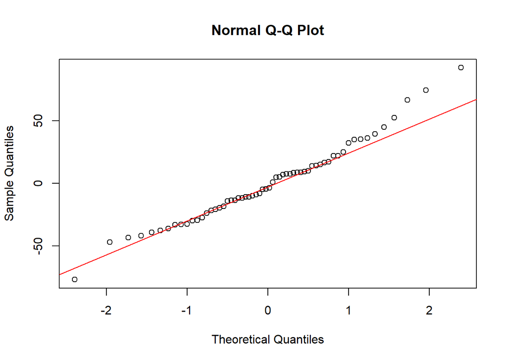

```r
qqnorm(residuals)
qqline(residuals, col = "red")
```

Finally, in (e.), we check for multicollinearity to assess whether the regressors are linearly independent.

```r
vif(fit)
```

```
##       X9       X6       X2      X14       X1       X3       X5
## 2.860830 1.746162 1.885043 1.404607 1.907630 1.815244 1.927692
```

With VIF values lesser than 5, there is a clear indication of low multicollinearity or independence between predictors.